# ເສດຖະສາດຈຸນລະພາກ

# 1. ເສດຖະສາດຈຸນລະພາກ ແມ່ນຫຍັງ?

## 1.1 ເສດຖະກິດ

ໃນທາງປະຕິບັດ ເສດຖະກິດ ແມ່ນ ການຜະລິດ, ບໍລິການ ແລະ ການຈັດການທີ່ກ່ຽວຂ້ອງ

ເຄົ້າຂອງ ຄຳວ່າເສດຖະກິດ ໃນແຕ່ລະພາສາ:

- ພາສາອັງກິດ economy ມາຈາກຄຳວ່າ oikonomia ໃນພາສາເກຣັກ ໝາຍຄວາມວ່າ ການບໍລິຫານບ້ານ
- ພາສາຍີ່ປຸ່ນ 経済 ຫຍໍ້ມາຈາກຄຳວ່າ 経世済民 ໃນພາສາຈີນບູຮານ ແປວ່າ ການບໍລິຫານປະທດ ເພື່ອກອບກູ້ປະຊາຊົນ. ນີ້ແມ່ນຕົວຢ່າງໜຶ່ງ ຂອງ ການທີ່ປະເທດຍີ່ປຸ່ນ ນຳໃຊ້ໂຕໜັງສືຈີນບູຮານ ເພື່ອແປຄວາມໝາຍຂອງຄຳສັບເຕັກນິກ ຈາກພາສາເອີຣົບຕາເວັນຕົກ ເປັນພາສາຍີ່ປຸ່ນ ໃນໄລຍະເລີ່ມຕົ້ນ ການຫັນເປັນທັນສະໄໝ
- ພາສາລາວ ເສດຖະກິດ ມາຈາກຄຳວ່າ សេដ្ឋកិច្ច ໃນພາສາກຳປູເຈຍ ແປວ່າ ການເຮັດໃຫ້ມີຫຼາຍ ໃຫ້ອຸດົມສົມບູນ

## 1.2 ເສດຖະສາດ

ແມ່ນ ການສຶກສາກ່ຽວກັບ ເສດຖະກິດ ທີ່ແບ່ງເປັນຫຼາຍສາຂາຍ່ອຍ ເຊັ່ນ:

- ເສດຖະສາດມະຫາພາກ (macroeconomics)
- ເສດຖະສາດຈຸນລະພາກ (microeconomics)
- ເສດຖະສາດພັດທະນາ (development economics)
- ປະຫວັດສາດເສດຖະກິດ (economic history)
- ເສດຖະສາດສາກົນ (international economics)
- ເສດຖະສາດສາທາລະນະ (public economics)
- ເສດຖະສາດແຮງງານ (labor economics)
- ທິດສະດີເກມ (game theory)
- ເສດຖະສາດພຶດຕິກຳ (behavioral economics)

ແລະອື່ນໆ

## 1.3 ເສດຖະສາດຈຸນລະພາກ

ສຶກສາກ່ຽວກັບປັດໃຈກະທົບຕໍ່ ການຕັດສິນໃຈ ຂອງຫົວໜ່ວຍຍ່ອຍຂອງເສດຖະກິດເຊັ່ນ ບຸກຄົນ, ຄົວເຮືອນ, ວິສະຫະກິດ

- ຂອບເຂດການສຶກສາ ຂອງ ເສດຖະກິດມະຫາພາກ ແລະ ເສດຖະກິດຈຸນລະພາກ

[figure not shown]

## 1.4 ຮຽນເສດຖະສາຈຸນລະພາກ ມີປະໂຫຍດຫຍັງ?

ຄວາມຮູ້ດ້ານເສດຖະສາດຈຸນລະພາກ ມີ ປະໂຫຍດຕ່າງກັນຕໍ່ແຕ່ລະສາຂາອາຊີບ ເຊັ່ນ:

- ລັດຖະກອນ: ບໍລິຫານອົງກອນໃນສັງກັດໃຫ້ມີປະສິດທິຜົນແນວໃດ
- ນັກທຸລະກິດ: ບໍລິຫານຊັບພະຍາກອນ ແລະ ປັດໃຈການຜະລິດແນວໃດ ໃຫ້ໄດ້ຜົນກຳໄລສູງສຸດ
- ຄົວເຮືອນ: ບໍລິຫານເສດຖະກິດຄອບຄົວແນວໃດ

## 1.5 ຄະນິດສາດພື້ນຖານຂອງເສດຖະສາດ

### 1.5.1 ຈຳນວນ

ຈຳນວນໃນຄະນິດສາດ ແບ່ງອອກເປັນ :

- ຈຳນວນທຳມະຊາດ 1, 2, 3, … ($\mathbb{N}$)
- ຈຳນວນຖ້ວນ …, -3, -2, -1, 0, 1, 2, 3, … ($\mathbb{Z}$)
- ຈຳນວນປົກກະຕິ ທີ່ສະແດງໄດ້ດ້ວຍອັດຕາສ່ວນ ຂອງ ຈຳນວນຖ້ວນ a/b ($\mathbb{Q}$)
- ຈຳນວນອະປົກກະຕິ ທີ່ສະແດງດ້ວຍອັດຕາສ່ວນຈຳນວນຖ້ວນບໍ່ໄດ້ $\small \pi$,$\sqrt{2}$, … ($\mathbb{Q'}$)
- ຈຳນວນຈິງ ຮວມເອົາທຸກໆຈຳນວນທາງເທິງ ($\mathbb{R}$)

ເສດຖະສາດນຳໃຊ້ ຈຳນວນທຳມະຊາດ, ຈຳນວນຖ້ວນ ແລະ ຈຳນວນປົກກະຕິເປັນຕົ້ນຕໍ.

### 1.5.2 ຕຳລາ

ຕຳລາແມ່ນ ຄວາມສຳພັນລະຫວ່າງ ສອງ ຫຼື ຫຼາຍຕົວປ່ຽນ ເຊັ່ນ:

- ນໍ້າໜັກ ແລະ ລວງສູງ
- ຄວາມຮູ້ ແລະ ຈຳນວນປຶ້ມທີ່ໄດ້ອ່ານ
- ຍອດຂາຍ ແລະ ລາຄາ

ສັນຍາລັກ ຂອງ ຕຳລາ ມັກໃຊ້ ຕົວອັກສອນ f ມາຈາກຄຳວ່າ function ໃນພາສາອັງກິດ. f(x) ແມ່ນ ຕຳລາ f ທີ່ x ເປັນຕົວປ່ຽນ. ເວລາ x ປ່ຽນແປງ ຄ່າຂອງ f(x) ກໍຈະປ່ຽນແປງ. ໃນຕົວຈິງ ຈະໃຊ້ຕົວອັກສອນ ຫຼື ສັນຍາລັກຫຍັງກໍໄດ້.

ຕົວຢ່າງ:

ນໍ້າໜັກ(ລວງສູງ) ອ່ານວ່າ ນໍ້າໜັກ ເປັນຕຳລາຂອງລວງສູງ. ຖ້າຕຳລາສະແດງເຖິງຄວາມສຳພັນແບບຊັດເຈນ ເວລາຮູ້ລວງສູງກໍຈະສາມາດຄິດໄລ່ ນໍ້າໜັກໄດ້

#### ຕຳລາຂັ້ນໜຶ່ງ

ຕຳລາເສັ້ນຊື່ ແມ່ນ ຕຳລາທີ່ສະແດງດ້ວຍ f(x,y,…)=a+bx+cy+…

f(x,y,…) ແມ່ນ ຄ່າຂອງຕຳລາ

a ແມ່ນ ຄ່າເລີ່ມຕົ້ນ

b,c,… ແມ່ນ ອັດຕາການປ່ຽນແປງ

x,y,… ແມ່ນ ຕົວປ່ຽນ

ບົດຝຶກຫັດ

1. ຖ້າ ຕຳລາຄວາມຕ້ອງການ ແມນ Q(P)=10-5P. ໃນນີ້ Q ແມ່ນປະລິມານຄວາມຕ້ອງການ ແລະ P ແມ່ນລາຄາ. ຖາມວ່າ ປະລິມານຄວາມຕ້ອງການ ແມ່ນ ເທົ່າໃດ ຖ້າລາຄາ ເທົ່າ (1) 0, (2) 1, (3) 2, (4) 3.
2. ຂຽນຕຳລາຄວາມຕ້ອງການເສື້ອ ຂອງນາງ ກ ຖ້າລາວຊື້ເສື້ອ 3 ຜືນເວລາລາຄາແມ່ນ 10000 ກີບ ແລະ 1 ຜືນເວລາລາຄາເທົ່າກັບ 30000 ກີບ.
3. ຖ້າ ຕຳລາການສະໜອງ ຂອງບໍລິສັດ ກ ແມ່ນ Q(P)=100-10P. ໃນນີ້ Q ແມ່ນປະລິມານການສະໜອງ ແລະ P ແມ່ນລາຄາ. ຖາມວ່າການສະໜອງ ແມ່ນເທົ່າໃດ ຖ້າລາຄາ ເທົ່າ (1) 5, (2) 10, (3) 20, (4) 30.
4. ບໍລິສັດ ກ ຜະລິດເຂົ້າໜົມ 1000 ກັບເວລາ ລາຄາແມ່ນ 10000 ກີບ ແລະ 2000 ກັບ ເວລາລາຄາແມ່ນ 20000. ຈົ່ງຂຽນຕຳລາການສະໜອງ ຂອງ ບໍລິສັດນີ້.
5. ຖ້າ ເຂົ້າຈີ້ ກ້ອນລະ 10000 ກີບ ແລະ ເຂົ້າ ກິໂລລະ 5 ພັນກີບ. ຖ້າ ທ້າວ ກ ມີງົບປະມານ ຊື້ ເຂົ້າ 10 ກິໂລ ແລະ ເຂົ້າຈີ່ 5 ກ້ອນ ຖາມວ່າ ງົບປະມານລາວເທົ່າໃດ?
6. ຕຳລາຄວາມພໍໃຈ ຂອງ ນາງ ກ ແມ່ນ U(x,y)=2x+6y. ລາຄາ x ແລະ y ແມ່ນ 10000 ແລະ 20000. ງົບປະມານ ນາງ ກ ແມ່ນ 15000 ກີບ ຖາມວ່າ ລາວຕ້ອງຊື້ x ແລະ y ຫຼາຍປານໃດເພື່ອໃຫ້ໄດ້ຄວາມພໍໃຈສູງສຸດ.
7. ຖ້າກິນເຂົ້າ 1 ກິໂລໄດ້ພະລັງານ 1000 ກິໂລກະລໍລີ, ກິນເຂົ້າຈີ່ 1 ກິໂລໄດ້ພະລັງງານ 2000 ກິໂລກະລໍລີ. ຖ້າ ລາຄາເຂົ້າ 1 ກິໂລ 2000 ກີບ ແລະ ເຂົ້າຈີ່ກິໂລ 20000 ກີບ. ຖ້າມີງົບປະມານ 150000 ຈະໃຊ້ແນວໃດເພື່ອໃຫ້ໄດ້ ພະລັງງານຫຼາຍທີ່ສຸດ.
8. ຖ້າໄດ້ເງິນເດືອນ 2 ລ້ານແລ້ວທ້ອນ 10% ທຸກເດືອນ 5 ປີຈະທ້ອນໄດ້ຫຼາຍປານໃດ?
9. ຖ້າໄດ້ເງິນເດືອນ 2 ລ້ານແລ້ວທ້ອນ 25% ທຸກເດືອນ 5 ປີຈະທ້ອນໄດ້ຫຼາຍປານໃດ?
10. ຖ້າອັດຕາດອກເບ້ຍເງິນຝາກ ແມ່ນ 5% ຕໍ່ຕົ້ນຕໍ່ປີ ເອົາເງິນ 10 ລ້ານກີບຝາກທະນາຄານ 10 ປີຈະມີເງິນຢູ່ທະນາຄານຫຼາຍປານໃດ?
11. ເຂົ້າລາຄາ 10000 ກີບຕໍ່ກິໂລ. ມີເງິນ 100000 ກີບຊື້ໄດ້ຈັກກິໂລ. ຖ້າເອົາເງິນໄປຝາກທະນາຄານ ດອກເບ້ຍຕໍ່ຕົ້ນ 5% ຕໍ່ປີ ແຕ່ລາຄາເຂົ້າເພີ່ມຂຶ້ນ 10% ຕໍ່ປີ, 10 ປີໜ້າຖອນມາຊື້ເຂົ້າໄດ້ຈັກກິໂລ?

#### ຕຳລາເລກກຳລັງ ແລະ ຜົນຕຳລາ (ອັດຕາປ່ຽນ)

ຮູບແບບຕຳລາເລກກຳລັງ f(x) = a + b$x^n$

ອັດຕາເພີ່ມຄົງທີ່

f(x) = ax

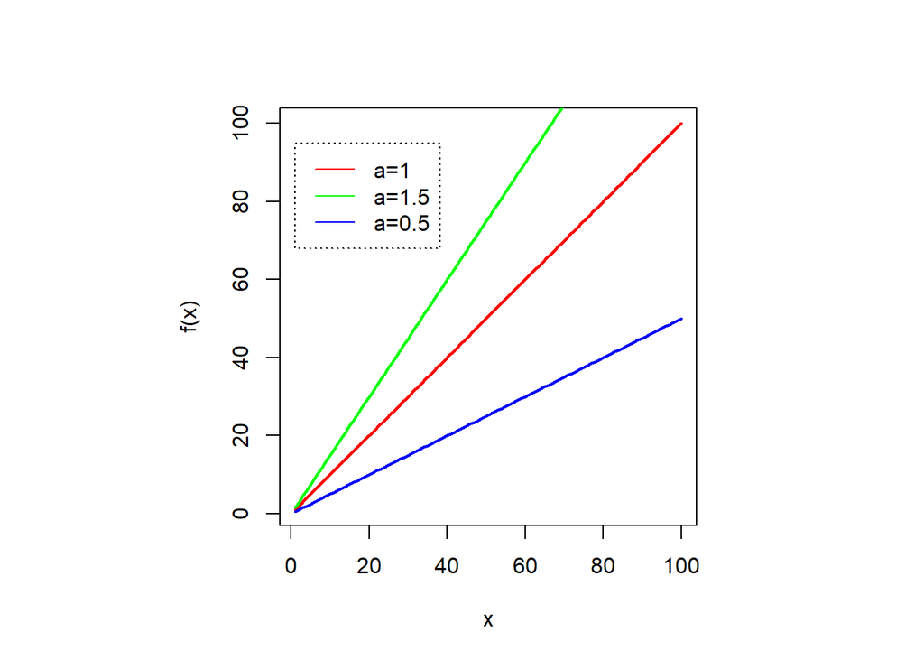

ອັດຕາເພີ່ມເລັ່ງ (n>1) f(x) = $x^n$

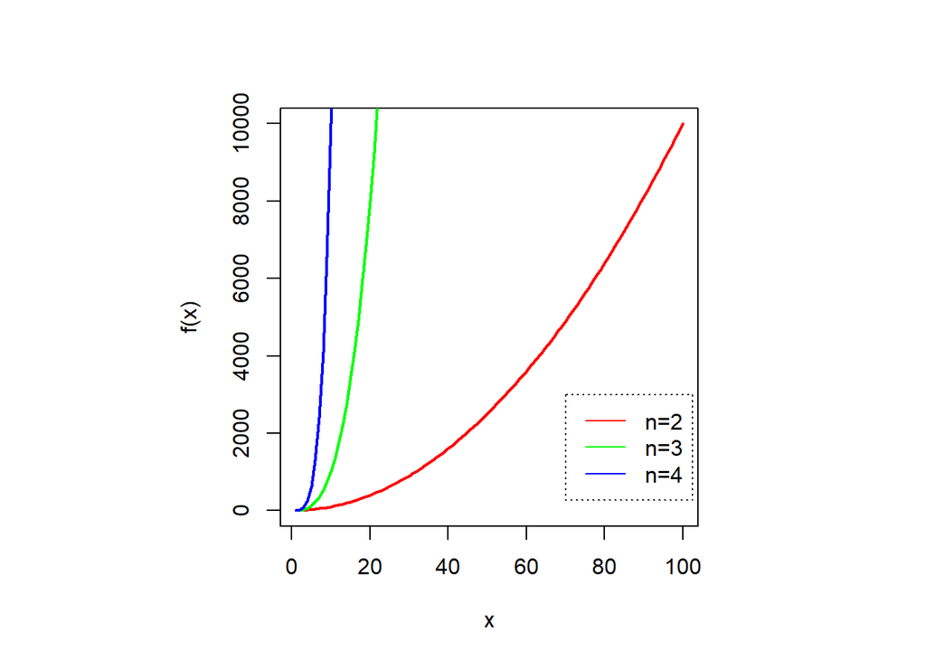

ອັດຕາເພີ່ມຜ່ອນ (n<1) f(x) = $x^{0.5}$

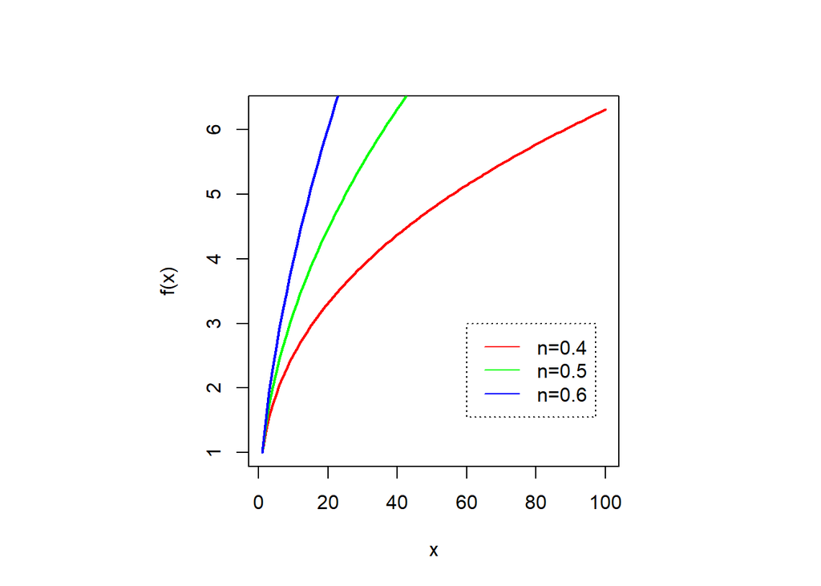

ສູດຜົນຕຳລາ

1. ຕຳລາ
   $$f(x) = ax^n$$
   ຜົນຕຳລາ
   $$f'(x) = anx^{n-1}$$

ຕົວຢ່າງ:

$$f(x) = 3x^2$$
$$f'(x) = 3\times2x^{2-1}$$
$$f'(x) = 6x$$

$$f(x) = 3x^{0.5}$$
$$f'(x) = 3\times0.5x^{0.5-1}$$
$$f'(x) = 1.5x^{-0.5}$$
(2) ຕຳລາ
$$f(x) = ax^n + bx^m$$
$$f'(x) = anx^{n-1} + bmx^{m-1}$$

# 2. ກົນໄກຕະຫຼາດ

## 2.1 ຄວາມຕ້ອງການ ແລະ ການສະໜອງ

### ຄວາມຕ້ອງການ

#### ຕົວຢ່າງເສັ້ນຄວາມຕ້ອງການ

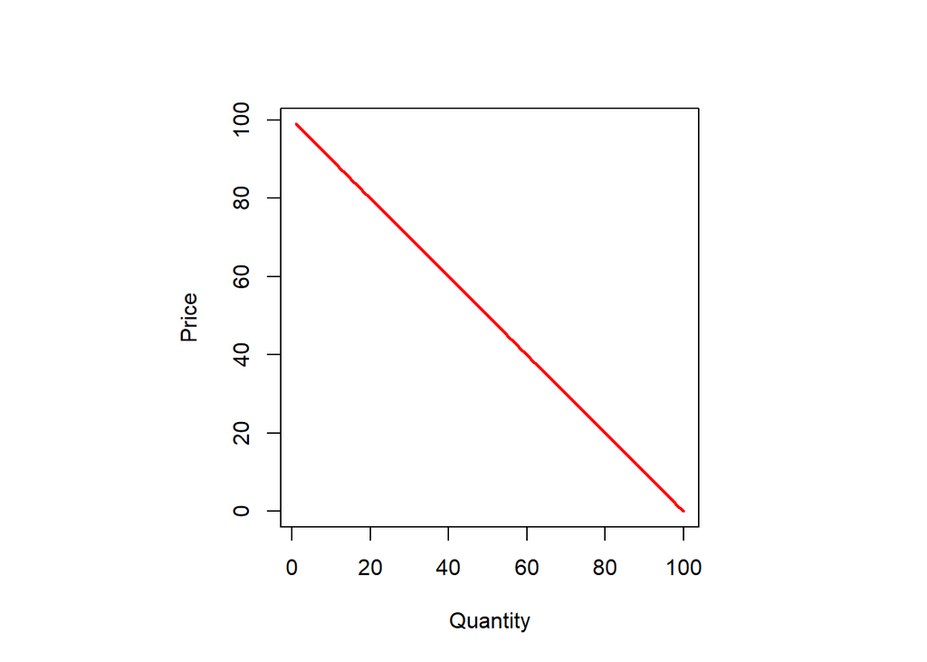

ສິ່ງທີ່ເຮັດໃຫ້ ເສັ້ນຄວາມຕ້ອງການ ເຄື່ອນຍ້າຍ

- ການປ່ຽນແປງ ລາຄາ ຂອງ ສິນຄ້າກ່ຽວຂ້ອງ
- ການປ່ຽນແປງ ລາຍຮັບ
- ການປ່ຽນແປງ ລົດນິຍົມ
- ການປ່ຽນແປງ ຄວາມຄາດຫວັງ
- ການປ່ຽນແປງ ຈຳນວນຜູ້ຊົມໃຊ້

ບົດຝຶກຫັດ:

ຖ້າ ກ ຊື້ ກະແລັມກິນຢູ່ຮ້ານ 1 ອັນ ເວລາລາຄາ ເທົ່າກັບ 20,000 ກີບ ແລະ 2 ອັນເວລາລາຄາ ເທົ່າກັບ 10,000 ກີບ ຖາມວ່າ ຕຳລາຄວາມຕ້ອງການກະແລັມ ແມ່ນຫຍັງ? ຄວາມຕ້ອງການສູງສຸດ ເທົ່າໃດ? ເມື່ອລາຄາກາຍເທົ່າໃດ ກ ຈະບໍ່ໍຊື້ກະແລັມເລີຍ?

#### ຕົວຢ່າງເສັ້ນການສະໜອງ

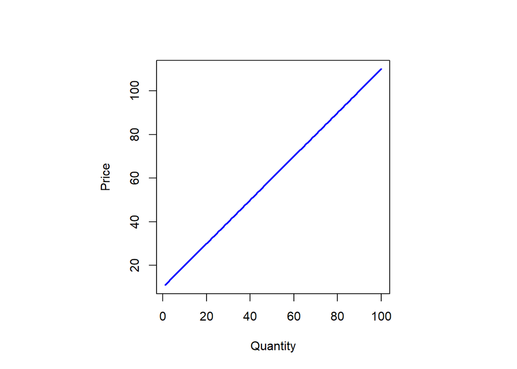

ສິ່ງທີ່ເຮັດໃຫ້ ເສັ້ນການສະໜອງ ເຄື່ອນຍ້າຍ

- ການປ່ຽນແປງ ລາຄາ ຂອງ ປັດໃຈການຜະລິດ
- ການປ່ຽນແປງ ລາຄາ ຂອງ ສິນຄ້າ ຫຼື ການບໍລິການທີ່ກ່ຽວຂ້ອງ
- ການປ່ຽນແປງ ເຕັກນິກການຜະລິດ
- ການປ່ຽນແປງ ຄວາມຄາດຫວັງ
- ການປ່ຽນແປງ ຈຳນວນຜູ້ຜະລິດ

ຖ້າ ບໍລິສັດ ກ ຜະລິດ ກະແລັມ 100 ອັນ ເວລາລາຄາ ເທົ່າກັບ 20,000 ກີບ ແລະ 200 ອັນເາລາຄາ ເທົ່າກັບ 25,000 ກີບ ຖາມວ່າ ຕະລາການສະໜອງກະແລັມ ຂອງ ບໍລິສັດ ກ ແມ່ນຫຍັງ? ປະລິມານການສະໜອງຕໍ່າສຸດເທົ່າໃດ? ເວລານັ້ນລາຄາເທົ່າໃດ?

#### ດຸນຍະພາບຕະຫຼາດ

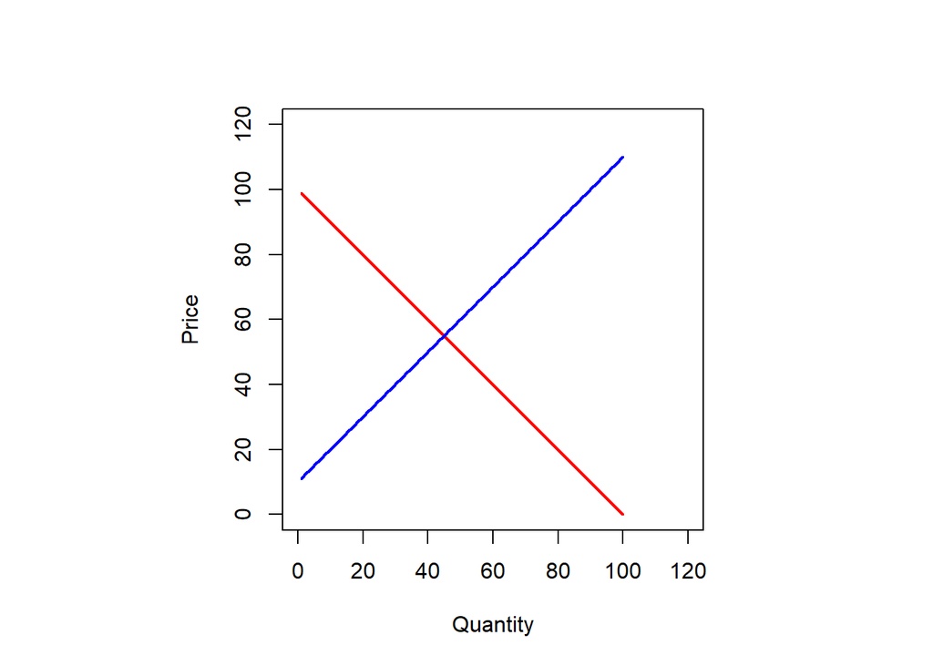

ບົດຝຶກຫັດ [ຄ່າອາຫານທ່ຽງ](https://forms.gle/XvZ5Ta1EVFCAc9u76)

ບົດຝຶກຫັດ [ຄ່າອາຫານຄໍ່າ](https://forms.gle/iwkVFN1cyMY2x3Zs5)

### 2.1.1 ຕະຫຼາດ

ປະເພດຕະຫຼາດ

- ຕະຫຼາດແຂ່ງຂັນສົມບູນ
  - ຕະຫຼາດທີ່ມີຜູ້ຜະລິດຈຳນວນຫຼວງຫຼາຍ ແລະ ບໍ່ມີຜູ້ຜະລິດໃດສາມາດກຳໜົດລາຄາສິນຄ້າໄດ້.
- ຕະຫຼາດແຂ່ງຂັນແບບຜູກຂາດ
  - ຕະຫຼາດທີ່ຜູກຂາດ ໂດຍ ຜູ້ຜະລິດສິນຄ້າທີ່ຈຳແນກໄດ້.
- ຕະຫຼາດຜູກຂາດໂດຍສ່ວນນ້ອຍ
  - ຕະຫຼາດທີ່ຜູກຂາດ ໂດຍ ບໍລິສັດຈຳນວນໜ້ອຍ.
- ຕະຫຼາດຜູກຂາດ
  - ຕະຫຼາດທີ່ຜູກຂາດໂດຍບໍລິສັດດຽວ. ຜູ້ຜະລິດສາມາດຕັ້ງລາຄາໄດ້ຕາມໃຈ ແຕ່ບໍ່ເກີນລາຄາສູງສຸດ ທີ່ ຜູ້ຊົມໃຊ້ພໍໃຈຈ່າຍ.

## 2.2 ການຂະຫຍາຍກຳໄລສູງສຸດ (profit maximization)

### 2.2.1 ລາຍຮັບ

ລາຍຮັບ ເທົ່າກັບ ປະລິມານ ຄູນ ໃຫ້ລາຄາ.

- ຕົວຢ່າງ
  - ຖ້າ ລາຄາ $p$ ເປັນ ຕຳລາຂອງ ປະລິມານ $q$ ໂດຍທີ່
    $$p(q) = 1000 - 10q$$
  - ລາຍຮັບ $r$ ເປັນຕຳລາ ຂອງ $q$ ແມ່ນ
    $$r(q) = p(q) * q = 1000q- 10q^2$$

### 2.2.2 ຕົ້ນທຶນ (ລາຍຈ່າຍ)

ລາຍຈ່າຍ ປະກອບມີ ລາຍຈ່າຍ(ຫຼືຕົ້ນທຶນ) ຄົງທີ່ ແລະ ລາຍຈ່າຍປ່ຽນແປງ.

### 2.2.3 ກຳໄລ

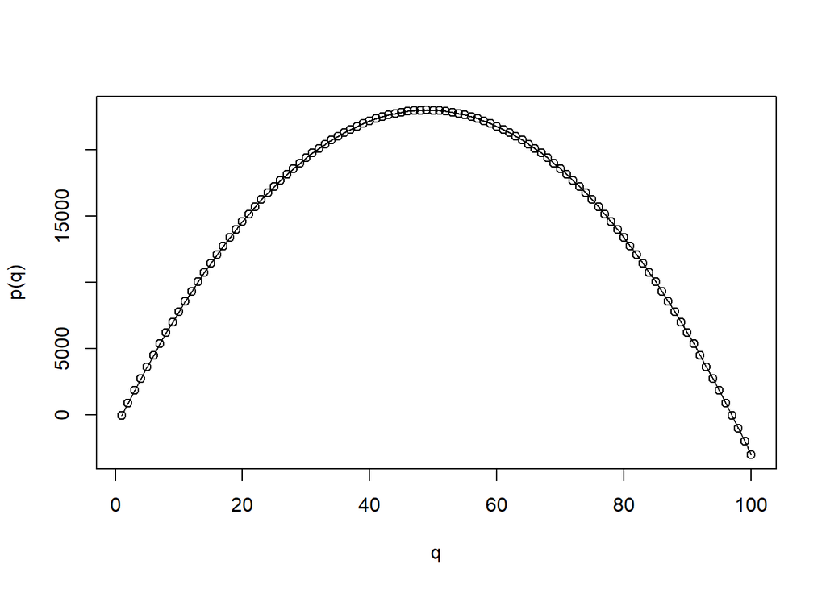

$$\pi'(q) = -2*10q+980 = 0$$
$$q = \frac{980}{20} = 49$$

$$\pi''(q) = -20 <0$$

ສະນັ້ນ $\pi$ ມີຄ່າສູງສຸດ ເວລາ
$$q = 49$$